# BellaBeat Analysis

Gabriele Fulcheri

2022-04-14

### *Structure of the analysis*

Since my focus is on Bellabeat’s fitness watch, I selected three main dataset among those available, namely the data regarding daily activity, hourly activity and sleep. Therefore, the analysis is divided in three parts, one for each of the aforementioned type of data.

### *Key aspects of the data available and aim of the analysis*

The dataset contains data regarding the activity of 33 different users. There are two main problems:

- 33 people could be not representative enough of the population Bellabeat wants to target with its marketing
- Notwithstanding the fact that Bellabeat’s products are designed for women, we haven’t gender related information (as well as other important demographic information such as age and country)

Moreover, since we haven’t data regarding the customer’s preferences and opinions about fitness products, the aim of my analysis will be to segment the 33 customers, in order to provide the basis for a future inquiry on each segment preferences and opinion about fitness watches.

### Libraries used

```r
library(readr)
library(tidyverse)
library(dplyr)
library(readr)
library(lubridate)
library(stringr)
library(data.table)
library(ggfortify)
library(stats)
library(ggplot2)
library(ggthemes)
library(knitr)
library(janitor)
library(skimr)
```

## Load Data

```r
dailyActivity_merged <- read_csv("//PC-GABRI/Users/Gabri/Documents/Fitabase Data 4.12.16-5.12.16/dailyActivity_merged.csv")
hourlyIntensities_merged <- read_csv("//PC-GABRI/Users/Gabri/Documents/Fitabase Data 4.12.16-5.12.16/hourlyIntensities_merged.csv")
hourlyCalories_merged <- read_csv("//PC-GABRI/Users/Gabri/Documents/Fitabase Data 4.12.16-5.12.16/hourlyCalories_merged.csv")
hourlySteps_merged <- read_csv("//PC-GABRI/Users/Gabri/Documents/Fitabase Data 4.12.16-5.12.16/hourlySteps_merged.csv")
sleepDay_merged <- read_csv("//PC-GABRI/Users/Gabri/Documents/Fitabase Data 4.12.16-5.12.16/sleepDay_merged.csv")
```

### PART 1: Daily Activity and Cluster analysis

##### 1.1 DATA CLEANING

Let’s have a quick peek on our data

```r
head(dailyActivity_merged)
```

```
## # A tibble: 6 x 15
##        Id ActivityDate TotalSteps TotalDistance TrackerDistance LoggedActivitie~
##     <dbl> <chr>             <dbl>         <dbl>           <dbl>            <dbl>
## 1  1.50e9 4/12/2016         13162          8.5             8.5                 0
## 2  1.50e9 4/13/2016         10735          6.97            6.97                0
## 3  1.50e9 4/14/2016         10460          6.74            6.74                0
## 4  1.50e9 4/15/2016          9762          6.28            6.28                0
## 5  1.50e9 4/16/2016         12669          8.16            8.16                0
## 6  1.50e9 4/17/2016          9705          6.48            6.48                0
## # ... with 9 more variables: VeryActiveDistance <dbl>,
## #   ModeratelyActiveDistance <dbl>, LightActiveDistance <dbl>,
## #   SedentaryActiveDistance <dbl>, VeryActiveMinutes <dbl>,
## #   FairlyActiveMinutes <dbl>, LightlyActiveMinutes <dbl>,
## #   SedentaryMinutes <dbl>, Calories <dbl>
```

```r
summary(dailyActivity_merged)
```

```
##        Id            ActivityDate         TotalSteps    TotalDistance
##  Min.   :1.504e+09   Length:940         Min.   :    0   Min.   : 0.000
##  1st Qu.:2.320e+09   Class :character   1st Qu.: 3790   1st Qu.: 2.620
##  Median :4.445e+09   Mode  :character   Median : 7406   Median : 5.245
##  Mean   :4.855e+09                      Mean   : 7638   Mean   : 5.490
##  3rd Qu.:6.962e+09                      3rd Qu.:10727   3rd Qu.: 7.713
##  Max.   :8.878e+09                      Max.   :36019   Max.   :28.030
##  TrackerDistance  LoggedActivitiesDistance VeryActiveDistance
##  Min.   : 0.000   Min.   :0.0000           Min.   : 0.000
##  1st Qu.: 2.620   1st Qu.:0.0000           1st Qu.: 0.000
##  Median : 5.245   Median :0.0000           Median : 0.210
##  Mean   : 5.475   Mean   :0.1082           Mean   : 1.503
##  3rd Qu.: 7.710   3rd Qu.:0.0000           3rd Qu.: 2.053
##  Max.   :28.030   Max.   :4.9421           Max.   :21.920
##  ModeratelyActiveDistance LightActiveDistance SedentaryActiveDistance
##  Min.   :0.0000           Min.   : 0.000      Min.   :0.000000
##  1st Qu.:0.0000           1st Qu.: 1.945      1st Qu.:0.000000
##  Median :0.2400           Median : 3.365      Median :0.000000
##  Mean   :0.5675           Mean   : 3.341      Mean   :0.001606
##  3rd Qu.:0.8000           3rd Qu.: 4.782      3rd Qu.:0.000000
##  Max.   :6.4800           Max.   :10.710      Max.   :0.110000
##  VeryActiveMinutes FairlyActiveMinutes LightlyActiveMinutes SedentaryMinutes
##  Min.   :  0.00    Min.   :  0.00      Min.   :  0.0        Min.   :   0.0
##  1st Qu.:  0.00    1st Qu.:  0.00      1st Qu.:127.0        1st Qu.: 729.8
##  Median :  4.00    Median :  6.00      Median :199.0        Median :1057.5
##  Mean   : 21.16    Mean   : 13.56      Mean   :192.8        Mean   : 991.2
##  3rd Qu.: 32.00    3rd Qu.: 19.00      3rd Qu.:264.0        3rd Qu.:1229.5
##  Max.   :210.00    Max.   :143.00      Max.   :518.0        Max.   :1440.0
##     Calories
##  Min.   :   0
##  1st Qu.:1828
##  Median :2134
##  Mean   :2304
##  3rd Qu.:2793
##  Max.   :4900
```

As we can see, for each column we have “0 values”, therefore we need to check the consistency of those rows. The following code creates two tables and uses the summary function again to compare the calories, in order to check for the consistency of data.

```r
Values <- dailyActivity_merged %>% select(1:15) %>% filter(TotalSteps > 0)
No_values <- dailyActivity_merged %>% select(1:15) %>% filter(TotalSteps == 0)
summary(No_values)
```

```
##        Id            ActivityDate         TotalSteps TotalDistance
##  Min.   :1.504e+09   Length:77          Min.   :0    Min.   :0
##  1st Qu.:1.928e+09   Class :character   1st Qu.:0    1st Qu.:0
##  Median :4.020e+09   Mode  :character   Median :0    Median :0
##  Mean   :4.831e+09                      Mean   :0    Mean   :0
##  3rd Qu.:6.776e+09                      3rd Qu.:0    3rd Qu.:0
##  Max.   :8.792e+09                      Max.   :0    Max.   :0
##  TrackerDistance LoggedActivitiesDistance VeryActiveDistance
##  Min.   :0       Min.   :0                Min.   :0
##  1st Qu.:0       1st Qu.:0                1st Qu.:0
##  Median :0       Median :0                Median :0
##  Mean   :0       Mean   :0                Mean   :0
##  3rd Qu.:0       3rd Qu.:0                3rd Qu.:0
##  Max.   :0       Max.   :0                Max.   :0
##  ModeratelyActiveDistance LightActiveDistance SedentaryActiveDistance
##  Min.   :0                Min.   :0           Min.   :0
##  1st Qu.:0                1st Qu.:0           1st Qu.:0
##  Median :0                Median :0           Median :0
##  Mean   :0                Mean   :0           Mean   :0
##  3rd Qu.:0                3rd Qu.:0           3rd Qu.:0
##  Max.   :0                Max.   :0           Max.   :0
##  VeryActiveMinutes FairlyActiveMinutes LightlyActiveMinutes SedentaryMinutes
##  Min.   : 0.0000   Min.   :0           Min.   :0            Min.   :  48
##  1st Qu.: 0.0000   1st Qu.:0           1st Qu.:0            1st Qu.:1440
##  Median : 0.0000   Median :0           Median :0            Median :1440
##  Mean   : 0.4286   Mean   :0           Mean   :0            Mean   :1389
##  3rd Qu.: 0.0000   3rd Qu.:0           3rd Qu.:0            3rd Qu.:1440
##  Max.   :33.0000   Max.   :0           Max.   :0            Max.   :1440
##     Calories
##  Min.   :   0
##  1st Qu.:1496
##  Median :1841
##  Mean   :1657
##  3rd Qu.:1980
##  Max.   :2664
```

```r
summary(Values)
```

```
##        Id            ActivityDate         TotalSteps    TotalDistance
##  Min.   :1.504e+09   Length:863         Min.   :    4   Min.   : 0.00
##  1st Qu.:2.320e+09   Class :character   1st Qu.: 4923   1st Qu.: 3.37
##  Median :4.445e+09   Mode  :character   Median : 8053   Median : 5.59
##  Mean   :4.858e+09                      Mean   : 8319   Mean   : 5.98
##  3rd Qu.:6.962e+09                      3rd Qu.:11092   3rd Qu.: 7.90
##  Max.   :8.878e+09                      Max.   :36019   Max.   :28.03
##  TrackerDistance  LoggedActivitiesDistance VeryActiveDistance
##  Min.   : 0.000   Min.   :0.0000           Min.   : 0.000
##  1st Qu.: 3.370   1st Qu.:0.0000           1st Qu.: 0.000
##  Median : 5.590   Median :0.0000           Median : 0.410
##  Mean   : 5.964   Mean   :0.1178           Mean   : 1.637
##  3rd Qu.: 7.880   3rd Qu.:0.0000           3rd Qu.: 2.275
##  Max.   :28.030   Max.   :4.9421           Max.   :21.920
##  ModeratelyActiveDistance LightActiveDistance SedentaryActiveDistance
##  Min.   :0.0000           Min.   : 0.000      Min.   :0.00000
##  1st Qu.:0.0000           1st Qu.: 2.345      1st Qu.:0.00000
##  Median :0.3100           Median : 3.580      Median :0.00000
##  Mean   :0.6182           Mean   : 3.639      Mean   :0.00175
##  3rd Qu.:0.8650           3rd Qu.: 4.895      3rd Qu.:0.00000
##  Max.   :6.4800           Max.   :10.710      Max.   :0.11000
##  VeryActiveMinutes FairlyActiveMinutes LightlyActiveMinutes SedentaryMinutes
##  Min.   :  0.00    Min.   :  0.00      Min.   :  0.0        Min.   :   0.0
##  1st Qu.:  0.00    1st Qu.:  0.00      1st Qu.:146.5        1st Qu.: 721.5
##  Median :  7.00    Median :  8.00      Median :208.0        Median :1021.0
##  Mean   : 23.02    Mean   : 14.78      Mean   :210.0        Mean   : 955.8
##  3rd Qu.: 35.00    3rd Qu.: 21.00      3rd Qu.:272.0        3rd Qu.:1189.0
##  Max.   :210.00    Max.   :143.00      Max.   :518.0        Max.   :1440.0
##     Calories
##  Min.   :  52
##  1st Qu.:1856
##  Median :2220
##  Mean   :2361
##  3rd Qu.:2832
##  Max.   :4900
```

```r
kable(No_values, caption = " Table 1: Values for completely sedentary days", format = "html") %>%
  kableExtra::kable_classic(full_width=FALSE) %>%
  kableExtra::scroll_box(width = "780px", height = "600px")
```

Table 1: Values for completely sedentary days

| Id | ActivityDate | TotalSteps | TotalDistance | TrackerDistance | LoggedActivitiesDistance | VeryActiveDistance | ModeratelyActiveDistance | LightActiveDistance | SedentaryActiveDistance | VeryActiveMinutes | FairlyActiveMinutes | LightlyActiveMinutes | SedentaryMinutes | Calories |
| --- | --- | --- | --- | --- | --- | --- | --- | --- | --- | --- | --- | --- | --- | --- |
| 1503960366 | 5/12/2016 | 0 | 0 | 0 | 0 | 0 | 0 | 0 | 0 | 0 | 0 | 0 | 1440 | 0 |
| 1844505072 | 4/24/2016 | 0 | 0 | 0 | 0 | 0 | 0 | 0 | 0 | 0 | 0 | 0 | 1440 | 1347 |
| 1844505072 | 4/25/2016 | 0 | 0 | 0 | 0 | 0 | 0 | 0 | 0 | 0 | 0 | 0 | 1440 | 1347 |
| 1844505072 | 4/26/2016 | 0 | 0 | 0 | 0 | 0 | 0 | 0 | 0 | 0 | 0 | 0 | 1440 | 1347 |
| 1844505072 | 5/2/2016 | 0 | 0 | 0 | 0 | 0 | 0 | 0 | 0 | 0 | 0 | 0 | 1440 | 1348 |
| 1844505072 | 5/7/2016 | 0 | 0 | 0 | 0 | 0 | 0 | 0 | 0 | 0 | 0 | 0 | 1440 | 1347 |
| 1844505072 | 5/8/2016 | 0 | 0 | 0 | 0 | 0 | 0 | 0 | 0 | 0 | 0 | 0 | 1440 | 1347 |
| 1844505072 | 5/9/2016 | 0 | 0 | 0 | 0 | 0 | 0 | 0 | 0 | 0 | 0 | 0 | 1440 | 1347 |
| 1844505072 | 5/10/2016 | 0 | 0 | 0 | 0 | 0 | 0 | 0 | 0 | 0 | 0 | 0 | 1440 | 1347 |
| 1844505072 | 5/11/2016 | 0 | 0 | 0 | 0 | 0 | 0 | 0 | 0 | 0 | 0 | 0 | 1440 | 1347 |
| 1844505072 | 5/12/2016 | 0 | 0 | 0 | 0 | 0 | 0 | 0 | 0 | 0 | 0 | 0 | 711 | 665 |
| 1927972279 | 4/16/2016 | 0 | 0 | 0 | 0 | 0 | 0 | 0 | 0 | 0 | 0 | 0 | 1440 | 2064 |
| 1927972279 | 4/17/2016 | 0 | 0 | 0 | 0 | 0 | 0 | 0 | 0 | 0 | 0 | 0 | 1440 | 2063 |
| 1927972279 | 4/19/2016 | 0 | 0 | 0 | 0 | 0 | 0 | 0 | 0 | 0 | 0 | 0 | 1440 | 2063 |
| 1927972279 | 4/20/2016 | 0 | 0 | 0 | 0 | 0 | 0 | 0 | 0 | 0 | 0 | 0 | 1440 | 2063 |
| 1927972279 | 4/21/2016 | 0 | 0 | 0 | 0 | 0 | 0 | 0 | 0 | 0 | 0 | 0 | 1440 | 2064 |
| 1927972279 | 4/27/2016 | 0 | 0 | 0 | 0 | 0 | 0 | 0 | 0 | 0 | 0 | 0 | 1440 | 2063 |
| 1927972279 | 4/29/2016 | 0 | 0 | 0 | 0 | 0 | 0 | 0 | 0 | 0 | 0 | 0 | 1440 | 2063 |
| 1927972279 | 4/30/2016 | 0 | 0 | 0 | 0 | 0 | 0 | 0 | 0 | 0 | 0 | 0 | 1440 | 2064 |
| 1927972279 | 5/5/2016 | 0 | 0 | 0 | 0 | 0 | 0 | 0 | 0 | 0 | 0 | 0 | 1440 | 2063 |
| 1927972279 | 5/8/2016 | 0 | 0 | 0 | 0 | 0 | 0 | 0 | 0 | 0 | 0 | 0 | 1440 | 2063 |
| 1927972279 | 5/9/2016 | 0 | 0 | 0 | 0 | 0 | 0 | 0 | 0 | 0 | 0 | 0 | 1440 | 2063 |
| 1927972279 | 5/10/2016 | 0 | 0 | 0 | 0 | 0 | 0 | 0 | 0 | 0 | 0 | 0 | 1440 | 2063 |
| 1927972279 | 5/11/2016 | 0 | 0 | 0 | 0 | 0 | 0 | 0 | 0 | 0 | 0 | 0 | 1440 | 2063 |
| 1927972279 | 5/12/2016 | 0 | 0 | 0 | 0 | 0 | 0 | 0 | 0 | 0 | 0 | 0 | 966 | 1383 |
| 4020332650 | 4/13/2016 | 0 | 0 | 0 | 0 | 0 | 0 | 0 | 0 | 0 | 0 | 0 | 1440 | 1981 |
| 4020332650 | 4/19/2016 | 0 | 0 | 0 | 0 | 0 | 0 | 0 | 0 | 0 | 0 | 0 | 1440 | 1980 |
| 4020332650 | 4/20/2016 | 0 | 0 | 0 | 0 | 0 | 0 | 0 | 0 | 0 | 0 | 0 | 1440 | 1980 |
| 4020332650 | 4/21/2016 | 0 | 0 | 0 | 0 | 0 | 0 | 0 | 0 | 0 | 0 | 0 | 1440 | 1980 |
| 4020332650 | 4/22/2016 | 0 | 0 | 0 | 0 | 0 | 0 | 0 | 0 | 0 | 0 | 0 | 1440 | 1980 |
| 4020332650 | 4/23/2016 | 0 | 0 | 0 | 0 | 0 | 0 | 0 | 0 | 0 | 0 | 0 | 1440 | 1980 |
| 4020332650 | 4/24/2016 | 0 | 0 | 0 | 0 | 0 | 0 | 0 | 0 | 0 | 0 | 0 | 1440 | 1980 |
| 4020332650 | 4/25/2016 | 0 | 0 | 0 | 0 | 0 | 0 | 0 | 0 | 0 | 0 | 0 | 1440 | 1980 |
| 4020332650 | 4/26/2016 | 0 | 0 | 0 | 0 | 0 | 0 | 0 | 0 | 0 | 0 | 0 | 1440 | 1980 |
| 4020332650 | 4/27/2016 | 0 | 0 | 0 | 0 | 0 | 0 | 0 | 0 | 0 | 0 | 0 | 1440 | 1980 |
| 4020332650 | 4/28/2016 | 0 | 0 | 0 | 0 | 0 | 0 | 0 | 0 | 0 | 0 | 0 | 1440 | 1980 |
| 4020332650 | 4/29/2016 | 0 | 0 | 0 | 0 | 0 | 0 | 0 | 0 | 0 | 0 | 0 | 1440 | 1980 |
| 4020332650 | 4/30/2016 | 0 | 0 | 0 | 0 | 0 | 0 | 0 | 0 | 0 | 0 | 0 | 1440 | 1980 |
| 4020332650 | 5/1/2016 | 0 | 0 | 0 | 0 | 0 | 0 | 0 | 0 | 0 | 0 | 0 | 1440 | 1980 |
| 4057192912 | 4/14/2016 | 0 | 0 | 0 | 0 | 0 | 0 | 0 | 0 | 0 | 0 | 0 | 1440 | 1776 |
| 4702921684 | 5/1/2016 | 0 | 0 | 0 | 0 | 0 | 0 | 0 | 0 | 0 | 0 | 0 | 1440 | 2017 |
| 5577150313 | 5/7/2016 | 0 | 0 | 0 | 0 | 0 | 0 | 0 | 0 | 0 | 0 | 0 | 1440 | 1819 |
| 5577150313 | 5/8/2016 | 0 | 0 | 0 | 0 | 0 | 0 | 0 | 0 | 0 | 0 | 0 | 1440 | 1819 |
| 6117666160 | 4/12/2016 | 0 | 0 | 0 | 0 | 0 | 0 | 0 | 0 | 0 | 0 | 0 | 1440 | 1496 |
| 6117666160 | 4/13/2016 | 0 | 0 | 0 | 0 | 0 | 0 | 0 | 0 | 0 | 0 | 0 | 1440 | 1496 |
| 6117666160 | 4/14/2016 | 0 | 0 | 0 | 0 | 0 | 0 | 0 | 0 | 0 | 0 | 0 | 1440 | 1496 |
| 6117666160 | 4/25/2016 | 0 | 0 | 0 | 0 | 0 | 0 | 0 | 0 | 0 | 0 | 0 | 1440 | 1497 |
| 6117666160 | 5/3/2016 | 0 | 0 | 0 | 0 | 0 | 0 | 0 | 0 | 0 | 0 | 0 | 1440 | 1496 |
| 6290855005 | 4/21/2016 | 0 | 0 | 0 | 0 | 0 | 0 | 0 | 0 | 0 | 0 | 0 | 1440 | 2060 |
| 6290855005 | 4/23/2016 | 0 | 0 | 0 | 0 | 0 | 0 | 0 | 0 | 33 | 0 | 0 | 1407 | 2664 |
| 6290855005 | 4/26/2016 | 0 | 0 | 0 | 0 | 0 | 0 | 0 | 0 | 0 | 0 | 0 | 1440 | 2060 |
| 6290855005 | 4/29/2016 | 0 | 0 | 0 | 0 | 0 | 0 | 0 | 0 | 0 | 0 | 0 | 1440 | 2060 |
| 6290855005 | 5/10/2016 | 0 | 0 | 0 | 0 | 0 | 0 | 0 | 0 | 0 | 0 | 0 | 1440 | 0 |
| 6775888955 | 4/12/2016 | 0 | 0 | 0 | 0 | 0 | 0 | 0 | 0 | 0 | 0 | 0 | 1440 | 1841 |
| 6775888955 | 4/19/2016 | 0 | 0 | 0 | 0 | 0 | 0 | 0 | 0 | 0 | 0 | 0 | 1440 | 1841 |
| 6775888955 | 4/21/2016 | 0 | 0 | 0 | 0 | 0 | 0 | 0 | 0 | 0 | 0 | 0 | 1440 | 1841 |
| 6775888955 | 4/23/2016 | 0 | 0 | 0 | 0 | 0 | 0 | 0 | 0 | 0 | 0 | 0 | 1440 | 1841 |
| 6775888955 | 4/27/2016 | 0 | 0 | 0 | 0 | 0 | 0 | 0 | 0 | 0 | 0 | 0 | 1440 | 1841 |
| 6775888955 | 4/29/2016 | 0 | 0 | 0 | 0 | 0 | 0 | 0 | 0 | 0 | 0 | 0 | 1440 | 1841 |
| 6775888955 | 5/2/2016 | 0 | 0 | 0 | 0 | 0 | 0 | 0 | 0 | 0 | 0 | 0 | 1440 | 1841 |
| 6775888955 | 5/4/2016 | 0 | 0 | 0 | 0 | 0 | 0 | 0 | 0 | 0 | 0 | 0 | 1440 | 1841 |
| 6775888955 | 5/5/2016 | 0 | 0 | 0 | 0 | 0 | 0 | 0 | 0 | 0 | 0 | 0 | 1440 | 1841 |
| 7007744171 | 5/4/2016 | 0 | 0 | 0 | 0 | 0 | 0 | 0 | 0 | 0 | 0 | 0 | 1440 | 1557 |
| 7007744171 | 5/7/2016 | 0 | 0 | 0 | 0 | 0 | 0 | 0 | 0 | 0 | 0 | 0 | 111 | 120 |
| 7086361926 | 4/17/2016 | 0 | 0 | 0 | 0 | 0 | 0 | 0 | 0 | 0 | 0 | 0 | 1440 | 1629 |
| 8253242879 | 4/30/2016 | 0 | 0 | 0 | 0 | 0 | 0 | 0 | 0 | 0 | 0 | 0 | 1440 | 0 |
| 8583815059 | 5/12/2016 | 0 | 0 | 0 | 0 | 0 | 0 | 0 | 0 | 0 | 0 | 0 | 1440 | 0 |
| 8792009665 | 4/17/2016 | 0 | 0 | 0 | 0 | 0 | 0 | 0 | 0 | 0 | 0 | 0 | 1440 | 1688 |
| 8792009665 | 4/18/2016 | 0 | 0 | 0 | 0 | 0 | 0 | 0 | 0 | 0 | 0 | 0 | 1440 | 1688 |
| 8792009665 | 4/19/2016 | 0 | 0 | 0 | 0 | 0 | 0 | 0 | 0 | 0 | 0 | 0 | 1440 | 1688 |
| 8792009665 | 4/25/2016 | 0 | 0 | 0 | 0 | 0 | 0 | 0 | 0 | 0 | 0 | 0 | 1440 | 1688 |
| 8792009665 | 5/5/2016 | 0 | 0 | 0 | 0 | 0 | 0 | 0 | 0 | 0 | 0 | 0 | 1440 | 1688 |
| 8792009665 | 5/6/2016 | 0 | 0 | 0 | 0 | 0 | 0 | 0 | 0 | 0 | 0 | 0 | 1440 | 1688 |
| 8792009665 | 5/7/2016 | 0 | 0 | 0 | 0 | 0 | 0 | 0 | 0 | 0 | 0 | 0 | 1440 | 1688 |
| 8792009665 | 5/8/2016 | 0 | 0 | 0 | 0 | 0 | 0 | 0 | 0 | 0 | 0 | 0 | 1440 | 1688 |
| 8792009665 | 5/9/2016 | 0 | 0 | 0 | 0 | 0 | 0 | 0 | 0 | 0 | 0 | 0 | 1440 | 1688 |
| 8792009665 | 5/10/2016 | 0 | 0 | 0 | 0 | 0 | 0 | 0 | 0 | 0 | 0 | 0 | 48 | 57 |

The data in the “No_Values” table is consistent. The days reported are days where customers were totally inactive. At first glance, it seems strange that the average calories consumed in those days is 1657, compared to 2361 of the active days. However, it is recognized that men can burn between 1600 and 1800 calories without exercise.

Let’s now check the consistency of the other columns

```r
dailyActivity_merged %>% duplicated() %>% sum()  ##for duplicates
```

```
## [1] 0
```

```r
rowSums(dailyActivity_merged[ ,c("VeryActiveDistance", "ModeratelyActiveDistance", "LightActiveDistance", "SedentaryActiveDistance")])  ## to check the consistency of the distance tracked
```

```
##   [1]  8.49  6.97  6.75  6.23  8.16  6.48  8.60  9.88  6.68  6.34  8.12  9.04
##  [13]  6.41  9.80  8.79 12.22  8.49  7.14  9.25  6.81  9.70  9.66  7.15  8.88
##  [25]  8.03  7.71  6.58  7.72  7.77  8.12  0.00  5.31  4.55  5.92  0.97  3.49
##  [37]  4.05  7.40  1.90  3.23  4.13  2.60  5.55  3.95  4.22  1.84  5.44  1.80
##  [49]  1.55  4.31 28.04  4.92  1.36  1.42  1.60  1.13  1.37  2.22  1.13  1.93
##  [61]  2.04  1.93  7.77  5.82  8.02  3.82 11.07  6.37  5.19  8.19  1.77  0.89
##  [73]  2.67  4.83  2.41  2.60  7.21  2.20  6.83  2.31 13.23  4.46  2.73  9.35
##  [85]  1.68  3.20  7.12  9.73  4.88  4.84  6.67  0.96  4.43  3.26  5.23  2.54
##  [97]  2.26  2.99  3.04  0.13  0.01  5.32  3.55  2.36  0.00  0.00  0.00  0.00
## [109]  4.56  3.25  2.65  1.71  0.00  2.68  1.37  1.48  0.03  0.00  0.00  0.00
## [121]  0.00  0.00  0.00  0.47  0.25  1.50  0.68  0.00  0.00  0.17  0.00  0.00
## [133]  0.00  0.10  2.04  1.45  0.11  2.60  0.00  1.16  0.00  0.00  1.87  2.62
## [145]  0.91  1.24  0.00  1.45  1.04  0.00  0.00  0.00  0.00  0.00  8.34  8.50
## [157]  7.51  8.03  7.09 11.41 10.06  8.53 10.67  8.75  9.32  4.21 10.28  8.01
## [169]  7.20  7.13  7.13  7.19 12.91  7.40  7.28  8.73  8.29  8.35  7.18  4.71
```

[output cut: 64 more lines]

```r
clean_names(dailyActivity_merged)  ## to clean the names of our variables
```

```
## # A tibble: 940 x 15
##            id activity_date total_steps total_distance tracker_distance
##         <dbl> <chr>               <dbl>          <dbl>            <dbl>
##  1 1503960366 4/12/2016           13162           8.5              8.5
##  2 1503960366 4/13/2016           10735           6.97             6.97
##  3 1503960366 4/14/2016           10460           6.74             6.74
##  4 1503960366 4/15/2016            9762           6.28             6.28
##  5 1503960366 4/16/2016           12669           8.16             8.16
##  6 1503960366 4/17/2016            9705           6.48             6.48
##  7 1503960366 4/18/2016           13019           8.59             8.59
##  8 1503960366 4/19/2016           15506           9.88             9.88
##  9 1503960366 4/20/2016           10544           6.68             6.68
## 10 1503960366 4/21/2016            9819           6.34             6.34
## # ... with 930 more rows, and 10 more variables:
## #   logged_activities_distance <dbl>, very_active_distance <dbl>,
## #   moderately_active_distance <dbl>, light_active_distance <dbl>,
## #   sedentary_active_distance <dbl>, very_active_minutes <dbl>,
## #   fairly_active_minutes <dbl>, lightly_active_minutes <dbl>,
## #   sedentary_minutes <dbl>, calories <dbl>
```

```r
n_distinct(dailyActivity_merged$Id)  ##to check if we have data for all 33 participants
```

```
## [1] 33
```

```r
dailyActivity_merged$Id = as.character(dailyActivity_merged$Id) ##to change Id from numeric to character, in order to                                                                       avoid problems when plotting
```

Since the data are consistent, we can now proceed with the analysis

##### 1.2 DATA ANALYSIS AND K-MEAN CLUSTERING

In this phase, I will obtain a summary for each Id, with the average values for each column. This will be the starting point for the clustering phase, where it will be possible to segment the 33 participants

```r
activity_summary <- dailyActivity_merged %>% group_by(Id) %>%
  summarise(average_steps = mean(TotalSteps),
            average_VeryActive_minutes= mean(VeryActiveMinutes),
            average_FairlyActive_minutes = mean(FairlyActiveMinutes),
            average_LightlyActive_minutes = mean(LightlyActiveMinutes),
            average_sedentary_minutes= mean(SedentaryMinutes),
            average_calories_burnt = mean(Calories),
            average_active_minutes = sum(average_VeryActive_minutes, average_LightlyActive_minutes, average_FairlyActive_minutes))

kable(activity_summary, caption= "Table 2: Average activity values for each distinct Id", format = "html")%>%
  kableExtra::kable_classic(full_width=FALSE) %>%
  kableExtra::scroll_box(width = "780px", height = "600px")
```

Table 2: Average activity values for each distinct Id

| Id | average_steps | average_VeryActive_minutes | average_FairlyActive_minutes | average_LightlyActive_minutes | average_sedentary_minutes | average_calories_burnt | average_active_minutes |
| --- | --- | --- | --- | --- | --- | --- | --- |
| 1503960366 | 12116.742 | 38.7096774 | 19.1612903 | 219.93548 | 848.1613 | 1816.419 | 277.80645 |
| 1624580081 | 5743.903 | 8.6774194 | 5.8064516 | 153.48387 | 1257.7419 | 1483.355 | 167.96774 |
| 1644430081 | 7282.967 | 9.5666667 | 21.3666667 | 178.46667 | 1161.8667 | 2811.300 | 209.40000 |
| 1844505072 | 2580.065 | 0.1290323 | 1.2903226 | 115.45161 | 1206.6129 | 1573.484 | 116.87097 |
| 1927972279 | 916.129 | 1.3225806 | 0.7741935 | 38.58065 | 1317.4194 | 2172.806 | 40.67742 |
| 2022484408 | 11370.645 | 36.2903226 | 19.3548387 | 257.45161 | 1112.5806 | 2509.968 | 313.09677 |
| 2026352035 | 5566.871 | 0.0967742 | 0.2580645 | 256.64516 | 689.4194 | 1540.645 | 257.00000 |
| 2320127002 | 4716.871 | 1.3548387 | 2.5806452 | 198.19355 | 1220.0968 | 1724.161 | 202.12903 |
| 2347167796 | 9519.667 | 13.5000000 | 20.5555556 | 252.50000 | 687.1667 | 2043.444 | 286.55556 |
| 2873212765 | 7555.774 | 14.0967742 | 6.1290323 | 308.00000 | 1097.1935 | 1916.968 | 328.22581 |
| 3372868164 | 6861.650 | 9.1500000 | 4.1000000 | 327.90000 | 1077.5500 | 1933.100 | 341.15000 |
| 3977333714 | 10984.567 | 18.9000000 | 61.2666667 | 174.76667 | 707.5333 | 1513.667 | 254.93333 |
| 4020332650 | 2267.226 | 5.1935484 | 5.3548387 | 76.93548 | 1237.2581 | 2385.806 | 87.48387 |
| 4057192912 | 3838.000 | 0.7500000 | 1.5000000 | 103.00000 | 1217.2500 | 1973.750 | 105.25000 |
| 4319703577 | 7268.839 | 3.5806452 | 12.3225806 | 228.77419 | 735.8065 | 2037.677 | 244.67742 |
| 4388161847 | 10813.935 | 23.1612903 | 20.3548387 | 229.35484 | 836.6774 | 3093.871 | 272.87097 |
| 4445114986 | 4796.548 | 6.6129032 | 1.7419355 | 209.09677 | 829.9032 | 2186.194 | 217.45161 |
| 4558609924 | 7685.129 | 10.3870968 | 13.7096774 | 284.96774 | 1093.6129 | 2033.258 | 309.06452 |
| 4702921684 | 8572.065 | 5.1290323 | 26.0322581 | 237.48387 | 766.4194 | 2965.548 | 268.64516 |
| 5553957443 | 8612.581 | 23.4193548 | 13.0000000 | 206.19355 | 668.3548 | 1875.677 | 242.61290 |
| 5577150313 | 8304.433 | 87.3333333 | 29.8333333 | 147.93333 | 754.4333 | 3359.633 | 265.10000 |
| 6117666160 | 7046.714 | 1.5714286 | 2.0357143 | 288.35714 | 796.2857 | 2261.143 | 291.96429 |
| 6290855005 | 5649.552 | 2.7586207 | 3.7931034 | 227.44828 | 1193.0345 | 2599.621 | 234.00000 |
| 6775888955 | 2519.692 | 11.0000000 | 14.8076923 | 40.15385 | 1299.4231 | 2131.769 | 65.96154 |
| 6962181067 | 9794.806 | 22.8064516 | 18.5161290 | 245.80645 | 662.3226 | 1982.032 | 287.12903 |
| 7007744171 | 11323.423 | 31.0384615 | 16.2692308 | 280.73077 | 1055.3462 | 2544.000 | 328.03846 |
| 7086361926 | 9371.774 | 42.5806452 | 25.3548387 | 143.83871 | 850.4516 | 2566.355 | 211.77419 |
| 8053475328 | 14763.290 | 85.1612903 | 9.5806452 | 150.96774 | 1148.0000 | 2945.806 | 245.70968 |
| 8253242879 | 6482.158 | 20.5263158 | 14.3157895 | 116.89474 | 1287.3684 | 1788.000 | 151.73684 |
| 8378563200 | 8717.710 | 58.6774194 | 10.2580645 | 156.09677 | 716.1290 | 3436.581 | 225.03226 |
| 8583815059 | 7198.516 | 9.6774194 | 22.1935484 | 138.29032 | 1267.2258 | 2732.032 | 170.16129 |
| 8792009665 | 1853.724 | 0.9655172 | 4.0344828 | 91.79310 | 1060.4828 | 1962.310 | 96.79310 |
| 8877689391 | 16040.032 | 66.0645161 | 9.9354839 | 234.70968 | 1112.8710 | 3420.258 | 310.70968 |

Let’s now proceed with the cluster analysis, based on the values obtained in the above table

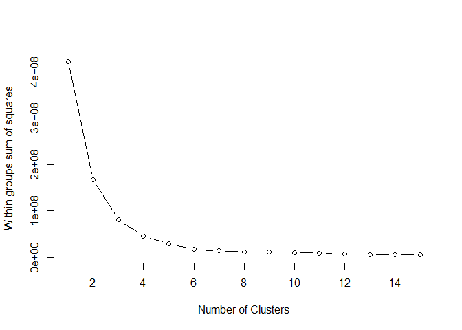

```
##  [1] 421500112 167176319  80403697  46059654  28988459  16963009  13663603
##  [8]  12097371  11093219  10646102   8882224   6732612   6131011   5555276
## [15]   4953675
```

```r
summary_data <- select(activity_summary, -1)  ## to avoid clustering based on Id values

wssplot <- function(data, nc=15, seed=1234){
  wss <- (nrow(data)-1)*sum(apply(data,2,var))
  for (i in 2:nc){
    set.seed(seed)
    wss[i] <- sum(kmeans(data, centers=i)$withinss)}
  plot(1:nc, wss, type="b", xlab="Number of Clusters",
       ylab="Within groups sum of squares")
  wss
}  ## to obtain the ideal number of cluster for the k-mean clustering

wssplot(summary_data)
```

Let’s now use the kmean() function to cluster the Id, based on n=4 (which is the optimal number of clusters, as we can see from the above wssplot)

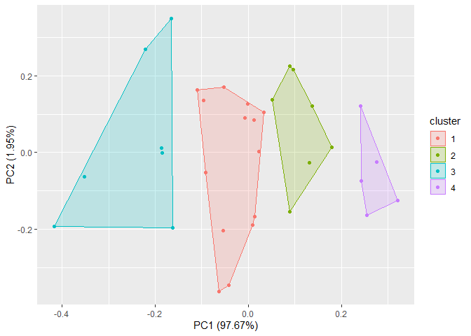

```r
KM = kmeans(summary_data,4)
autoplot(KM, summary_data, frame=TRUE)
```

The clustering has divided the Ids into 4 groups, based on four centers with the following values:

```r
as.data.frame(KM$centers) %>% kable(caption= "Table 3: Clusters centers", format= "html") %>%
  kableExtra::kable_classic(full_width=FALSE) %>%
  kableExtra::scroll_box(width = "780px", height = "600px")
```

Table 3: Clusters centers

| average_steps | average_VeryActive_minutes | average_FairlyActive_minutes | average_LightlyActive_minutes | average_sedentary_minutes | average_calories_burnt | average_active_minutes |
| --- | --- | --- | --- | --- | --- | --- |
| 8128.045 | 22.248305 | 16.100528 | 224.61491 | 881.0585 | 2425.339 | 262.96374 |
| 5256.272 | 5.825267 | 4.285141 | 180.68034 | 1099.2592 | 1899.389 | 190.79075 |
| 12487.519 | 42.760794 | 22.274714 | 221.13097 | 974.4528 | 2549.141 | 286.16648 |
| 2027.367 | 3.722136 | 5.252306 | 72.58294 | 1224.2392 | 2045.235 | 81.55738 |

Let’s now complete the activity summary table, adding to each Ids its cluster

```r
clusters <- data.frame(activity_summary, KM$cluster) %>% arrange(KM$cluster)

kable(clusters, format = "html", caption = "Table 4: Clusters assigned to each Id")%>%
  kableExtra::kable_classic(full_width=FALSE) %>%
  kableExtra::scroll_box(width = "780px", height = "600px")
```

Table 4: Clusters assigned to each Id

| Id | average_steps | average_VeryActive_minutes | average_FairlyActive_minutes | average_LightlyActive_minutes | average_sedentary_minutes | average_calories_burnt | average_active_minutes | KM.cluster |
| --- | --- | --- | --- | --- | --- | --- | --- | --- |
| 1644430081 | 7282.967 | 9.5666667 | 21.3666667 | 178.46667 | 1161.8667 | 2811.300 | 209.40000 | 1 |
| 2347167796 | 9519.667 | 13.5000000 | 20.5555556 | 252.50000 | 687.1667 | 2043.444 | 286.55556 | 1 |
| 2873212765 | 7555.774 | 14.0967742 | 6.1290323 | 308.00000 | 1097.1935 | 1916.968 | 328.22581 | 1 |
| 3372868164 | 6861.650 | 9.1500000 | 4.1000000 | 327.90000 | 1077.5500 | 1933.100 | 341.15000 | 1 |
| 4319703577 | 7268.839 | 3.5806452 | 12.3225806 | 228.77419 | 735.8065 | 2037.677 | 244.67742 | 1 |
| 4558609924 | 7685.129 | 10.3870968 | 13.7096774 | 284.96774 | 1093.6129 | 2033.258 | 309.06452 | 1 |
| 4702921684 | 8572.065 | 5.1290323 | 26.0322581 | 237.48387 | 766.4194 | 2965.548 | 268.64516 | 1 |
| 5553957443 | 8612.581 | 23.4193548 | 13.0000000 | 206.19355 | 668.3548 | 1875.677 | 242.61290 | 1 |
| 5577150313 | 8304.433 | 87.3333333 | 29.8333333 | 147.93333 | 754.4333 | 3359.633 | 265.10000 | 1 |
| 6117666160 | 7046.714 | 1.5714286 | 2.0357143 | 288.35714 | 796.2857 | 2261.143 | 291.96429 | 1 |
| 6962181067 | 9794.806 | 22.8064516 | 18.5161290 | 245.80645 | 662.3226 | 1982.032 | 287.12903 | 1 |
| 7086361926 | 9371.774 | 42.5806452 | 25.3548387 | 143.83871 | 850.4516 | 2566.355 | 211.77419 | 1 |
| 8378563200 | 8717.710 | 58.6774194 | 10.2580645 | 156.09677 | 716.1290 | 3436.581 | 225.03226 | 1 |
| 8583815059 | 7198.516 | 9.6774194 | 22.1935484 | 138.29032 | 1267.2258 | 2732.032 | 170.16129 | 1 |
| 1624580081 | 5743.903 | 8.6774194 | 5.8064516 | 153.48387 | 1257.7419 | 1483.355 | 167.96774 | 2 |
| 2026352035 | 5566.871 | 0.0967742 | 0.2580645 | 256.64516 | 689.4194 | 1540.645 | 257.00000 | 2 |
| 2320127002 | 4716.871 | 1.3548387 | 2.5806452 | 198.19355 | 1220.0968 | 1724.161 | 202.12903 | 2 |
| 4057192912 | 3838.000 | 0.7500000 | 1.5000000 | 103.00000 | 1217.2500 | 1973.750 | 105.25000 | 2 |
| 4445114986 | 4796.548 | 6.6129032 | 1.7419355 | 209.09677 | 829.9032 | 2186.194 | 217.45161 | 2 |
| 6290855005 | 5649.552 | 2.7586207 | 3.7931034 | 227.44828 | 1193.0345 | 2599.621 | 234.00000 | 2 |
| 8253242879 | 6482.158 | 20.5263158 | 14.3157895 | 116.89474 | 1287.3684 | 1788.000 | 151.73684 | 2 |
| 1503960366 | 12116.742 | 38.7096774 | 19.1612903 | 219.93548 | 848.1613 | 1816.419 | 277.80645 | 3 |
| 2022484408 | 11370.645 | 36.2903226 | 19.3548387 | 257.45161 | 1112.5806 | 2509.968 | 313.09677 | 3 |
| 3977333714 | 10984.567 | 18.9000000 | 61.2666667 | 174.76667 | 707.5333 | 1513.667 | 254.93333 | 3 |
| 4388161847 | 10813.935 | 23.1612903 | 20.3548387 | 229.35484 | 836.6774 | 3093.871 | 272.87097 | 3 |
| 7007744171 | 11323.423 | 31.0384615 | 16.2692308 | 280.73077 | 1055.3462 | 2544.000 | 328.03846 | 3 |
| 8053475328 | 14763.290 | 85.1612903 | 9.5806452 | 150.96774 | 1148.0000 | 2945.806 | 245.70968 | 3 |
| 8877689391 | 16040.032 | 66.0645161 | 9.9354839 | 234.70968 | 1112.8710 | 3420.258 | 310.70968 | 3 |
| 1844505072 | 2580.065 | 0.1290323 | 1.2903226 | 115.45161 | 1206.6129 | 1573.484 | 116.87097 | 4 |
| 1927972279 | 916.129 | 1.3225806 | 0.7741935 | 38.58065 | 1317.4194 | 2172.806 | 40.67742 | 4 |
| 4020332650 | 2267.226 | 5.1935484 | 5.3548387 | 76.93548 | 1237.2581 | 2385.806 | 87.48387 | 4 |
| 6775888955 | 2519.692 | 11.0000000 | 14.8076923 | 40.15385 | 1299.4231 | 2131.769 | 65.96154 | 4 |
| 8792009665 | 1853.724 | 0.9655172 | 4.0344828 | 91.79310 | 1060.4828 | 1962.310 | 96.79310 | 4 |

```r
clusters %>% count(KM.cluster) ## total number of Id for each cluster
```

```
##   KM.cluster  n
## 1          1 14
## 2          2  7
## 3          3  7
## 4          4  5
```

(N.B: minutes of exercise = Very Active Minutes + Fairly Active Minutes)

##### *Conclusion 1*: Almost an half of the total customer considered have either a very sedentary routine or an active one (if we consider group 2 and 3 together).

### PART 2: Hourly Activity

##### 2.1 DATA CLEANING

First, we join the three datasets regarding hourly data

```r
hourly_Activity <- full_join(x=hourlyIntensities_merged, y=hourlyCalories_merged, by.x="Id", by.y="Id")
Hourly_Activity <- full_join(x=hourly_Activity, y=hourlySteps_merged,by.x="Id",by.y="Id")
```

Cleaning date and hour format, Id format and checking the number of participants

```r
Hourly_Activity$ActivityHour=as.POSIXct(Hourly_Activity$ActivityHour, format="%m/%d/%Y %I:%M:%S %p", tz=Sys.timezone())
Hourly_Activity$Id=as.character(Hourly_Activity$Id)

Hourly_Activity$ActivityDay = format(Hourly_Activity$ActivityHour, format= "%m/%d/%y")
Hourly_Activity$ActivityTime = format(Hourly_Activity$ActivityHour, format= "%H:%M:%S")

n_distinct(Hourly_Activity$Id)
```

```
## [1] 33
```

Since data are now consistent, we can proceed with the analysis

##### 2.2 DATA ANALYSIS

The most important aspect to explore is in which hours the participants, as an unique group, are most active

```r
Group_Activity <- Hourly_Activity %>%
  group_by(ActivityTime) %>%
  summarise( average_group_intensity = mean(AverageIntensity),
             average_group_steps = mean(StepTotal))%>%
  as.data.frame()
kable(Group_Activity, format = "html", caption = "Table 5: Group Activity")%>%
  kableExtra::kable_classic(full_width=FALSE) %>%
  kableExtra::scroll_box(width = "780px", height = "600px")
```

Table 5: Group Activity

| ActivityTime | average_group_intensity | average_group_steps |
| --- | --- | --- |
| 00:00:00 | 0.0354925 | 42.188437 |
| 01:00:00 | 0.0236513 | 23.102894 |
| 02:00:00 | 0.0173991 | 17.110397 |
| 03:00:00 | 0.0073955 | 6.426581 |
| 04:00:00 | 0.0105508 | 12.699571 |
| 05:00:00 | 0.0825108 | 43.869099 |
| 06:00:00 | 0.1295202 | 178.508056 |
| 07:00:00 | 0.1788937 | 306.049409 |
| 08:00:00 | 0.2444683 | 427.544576 |
| 09:00:00 | 0.2564626 | 433.301826 |
| 10:00:00 | 0.2940617 | 481.665231 |
| 11:00:00 | 0.2820209 | 456.886731 |
| 12:00:00 | 0.3307845 | 548.642082 |
| 13:00:00 | 0.3129207 | 537.698154 |
| 14:00:00 | 0.3144770 | 540.513572 |
| 15:00:00 | 0.2597450 | 406.319126 |
| 16:00:00 | 0.2952775 | 496.845645 |
| 17:00:00 | 0.3609272 | 550.232892 |
| 18:00:00 | 0.3653606 | 599.169978 |
| 19:00:00 | 0.3564202 | 583.390729 |
| 20:00:00 | 0.2389993 | 353.905077 |
| 21:00:00 | 0.2012155 | 308.138122 |
| 22:00:00 | 0.1510509 | 237.987832 |
| 23:00:00 | 0.0832780 | 122.132890 |

Let’s now plot this values:

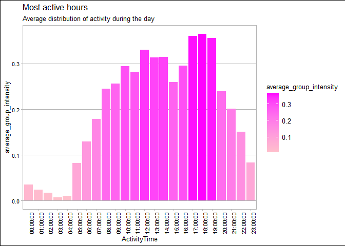

```r
ggplot(data= Group_Activity, aes(x=ActivityTime, y=average_group_intensity, fill = average_group_intensity)) + geom_histogram(stat = "identity")+
      scale_fill_gradient(low="pink", high= "magenta")+
      theme_calc()+
      theme(axis.text.x = element_text(angle=90))+
      labs(title= "Most active hours", subtitle="Average distribution of activity during the day")
```

##### *Conclusion 2* : Generally, the customers considered are mainy active between 17:00 and 19:00. We could conclude that they could be workers or students with an 8 hours study/work routine, that find time to workout after their working/studying schedules.

### PART 3: sleep

##### 3.1 DATA CLEANING

As for the precedent part, we need to clean the date and time format, Id datatype and look for duplicates

```r
sleepDay_merged$SleepDay=as.POSIXct(sleepDay_merged$SleepDay, format="%m/%d/%Y %I:%M:%S %p", tz=Sys.timezone())
sleepDay_merged$Id=as.character(sleepDay_merged$Id)
sum(duplicated(sleepDay_merged))
```

```
## [1] 3
```

Since we have found 3 duplicates rows, we need to select only distinct values:

```r
sleepDay_cleaned <- distinct(sleepDay_merged)
```

Let’s now check if we have data for all the 33 customers

```r
n_distinct(sleepDay_merged$Id)
```

```
## [1] 24
```

Since we have only 24 different Ids, let’s take a look at the number of unique entries for each of these 24 different users

```r
Unique_entries <- sleepDay_cleaned %>% group_by(Id) %>%
      summarise( n_entries = n_distinct(TotalMinutesAsleep))%>%
      arrange(n_entries)%>%
      as.data.frame()
kable(Unique_entries, format = "html", caption = "Table 6: Unique entries")%>%
  kableExtra::kable_classic(full_width=FALSE) %>%
  kableExtra::scroll_box(width = "443px", height = "600px")
```

Table 6: Unique entries

| Id | n_entries |
| --- | --- |
| 2320127002 | 1 |
| 7007744171 | 2 |
| 1844505072 | 3 |
| 6775888955 | 3 |
| 8053475328 | 3 |
| 1644430081 | 4 |
| 1927972279 | 5 |
| 4558609924 | 5 |
| 4020332650 | 8 |
| 2347167796 | 15 |
| 8792009665 | 15 |
| 6117666160 | 17 |
| 7086361926 | 21 |
| 4388161847 | 23 |
| 1503960366 | 24 |
| 2026352035 | 24 |
| 4319703577 | 24 |
| 4445114986 | 24 |
| 4702921684 | 25 |
| 5577150313 | 26 |
| 3977333714 | 27 |
| 8378563200 | 29 |
| 5553957443 | 30 |
| 6962181067 | 30 |

Let’s see if there is a proportion between a low number of entries and the total sleep tracked

```r
Total_Sleep <- aggregate(x = sleepDay_cleaned$TotalMinutesAsleep, by=list(sleepDay_cleaned$Id), FUN = sum) %>%
  arrange(x)%>%
  as.data.frame()

Final_check <- merge( x=Unique_entries, y=Total_Sleep, by.x = "Id", by.y= "Group.1") %>% arrange(n_entries)
kable(Final_check, format = "html", caption = "Table 7: Final check for cleaning")%>%
  kableExtra::kable_classic(full_width=FALSE) %>%
  kableExtra::scroll_box(width = "780px", height = "600px")
```

Table 7: Final check for cleaning

| Id | n_entries | x |
| --- | --- | --- |
| 2320127002 | 1 | 61 |
| 7007744171 | 2 | 137 |
| 1844505072 | 3 | 1956 |
| 6775888955 | 3 | 1049 |
| 8053475328 | 3 | 891 |
| 1644430081 | 4 | 1176 |
| 1927972279 | 5 | 2085 |
| 4558609924 | 5 | 638 |
| 4020332650 | 8 | 2795 |
| 2347167796 | 15 | 6702 |
| 8792009665 | 15 | 6535 |
| 6117666160 | 17 | 8618 |
| 7086361926 | 21 | 10875 |
| 4388161847 | 23 | 9204 |
| 1503960366 | 24 | 9007 |
| 2026352035 | 24 | 14173 |
| 4319703577 | 24 | 12393 |
| 4445114986 | 24 | 10785 |
| 4702921684 | 25 | 11272 |
| 5577150313 | 26 | 11232 |
| 3977333714 | 27 | 8222 |
| 8378563200 | 29 | 13799 |
| 5553957443 | 30 | 14368 |
| 6962181067 | 30 | 13888 |

As it is possible to see, 9 out of 24 users have tracked less than 10 days of sleep. This means that in our analysis we should exclude them and assume that 15 days tracked is a fair number in order to have meaningful data. Therefore, we need to create a table with only those Id that have enough tracked days:

```r
d_1 <- merge.data.frame(x=sleepDay_cleaned, y=Unique_entries, by.x= "Id", by.y = "Id")


d_2 <- d_1 %>% group_by(Id)%>% select(1:6) %>% filter(n_entries >= 15)

sleepDay_filtered <- d_2 %>% select(1:5)
```

##### 3.2 DATA ANALYSIS

Let’s now explore the 15 users’ sleep habit

```r
sleepDay_filtered %>% group_by(Id) %>%
   summarise(average_sleep_hours = mean(TotalMinutesAsleep/60)) %>% kable(format = "html", caption = "Table 8: Sleep Day Cleaned")%>%
  kableExtra::kable_classic(full_width=FALSE) %>%
  kableExtra::scroll_box(width = "780px", height = "600px")
```

Table 8: Sleep Day Cleaned

| Id | average_sleep_hours |
| --- | --- |
| 1503960366 | 6.004667 |
| 2026352035 | 8.436310 |
| 2347167796 | 7.446667 |
| 3977333714 | 4.894048 |
| 4319703577 | 7.944231 |
| 4388161847 | 6.669565 |
| 4445114986 | 6.419643 |
| 4702921684 | 6.958025 |
| 5553957443 | 7.724731 |
| 5577150313 | 7.200000 |
| 6117666160 | 7.979630 |
| 6962181067 | 7.466667 |
| 7086361926 | 7.552083 |
| 8378563200 | 7.418817 |
| 8792009665 | 7.261111 |

As it is possible to see, excluding one user with an average of 4.89 hours of sleep, the others sleep an average of 7 hours a day, which is a very common value, even if 8 hours are generally recommended. It seems that we haven’t interesting pattern to analyze. However, from this analysis it is possible to draw 2 conclusions:

##### *Conclusion 3* : Customers have an average of, more or less, 7 hours of sleep per day, which is in line with the hypothesis of part 2, namely that they have some school or work routine

##### *Conclusion 4*: Tracking sleep seems to be not a popular choice among customers. Are they not interested at all or is the watch or product itself uncomfortable to wear while sleeping?

### *Final marketing recommendations*

- Cluster analysis has revealed that customers are mainly segmented into two parts: active to very active customers and very sedentary ones. It is up to the manager to decided which segment to target, but it is certain that two completely different marketing campaign need to be designed
- Considering the hourly activity, it seems that, on average, customers have a standard routine that allows them to do fitness related activity mainly between 17:00 and 19:00. This is also confirmed by the analysis on sleep habit. If this is true, Bellabeat advertisement and placement strategies could focus on how fitness is related to working and studying routines
- Since tracking sleep is not popular among customers, Bellabeat could insist on the importance of tracking sleep in order to have a complete insight on our personal wellness. Manager should also investigate the reasons why customers are not willing to track their sleep: is it not interesting for them or is a watch uncomfortable to wear while sleeping? My final recommendation would be to create a customer questionnaire to investigate further this topic